# Practical Machine Learning course project

Georgi Pamukov

16 January 2017

## Executive summary:

The purpose of this project is to train Machine Learning model that will be capable of recognizing how well people perform particular physical activity (weight lifting). The data used is from accelerometers on the belt, forearm, arm, and dumbell of 6 participants - and the goal is to classify the observation in one of 5 possible categories (1 correct - and 4 common mistakes).

```r
# Load the necessary gear
library(dplyr)
library(caret)
library(randomForest)
```

## Getting and cleansing data:

Read data file and remove irrelevant features - I don’t want to include user or time/sequence related identifiers (that will just overfit the model on the particular dataset - and will basically make it unusable for generic cases).

```r
setwd('C:\\Users\\georgi.pamukov\\Desktop\\ds\\ml\\ml_proj\\data')
tr <- read.csv('pml-training.csv', stringsAsFactors=FALSE, strip.white=TRUE)
tr <- tr %>% select(-X,-user_name,-cvtd_timestamp, -raw_timestamp_part_1, -raw_timestamp_part_2, -new_window, -num_window)
```

Perform some cleansing and conversion: set ‘#DIV/0!’ values to 0, set ’’ to na, remove whitespaces, convert to numeric:

```r
tr_m <- as.matrix(tr[-153])
tr_m[tr_m=='#DIV/0!' & !is.na(tr_m)] <- '0'
tr_m[tr_m=='' & !is.na(tr_m)] <- NA
tr_m <- apply(tr_m, 2, function(x)gsub('\\s+', '',x))
tr_m <- apply(tr_m, 2, function(x)as.numeric(x))
tr <- cbind(data.frame(tr_m), classe=tr$classe)
tr_m <- NULL
```

Asses missing values - and get rid of columns that are more than 97% unpopulated (not seeing any pattern in their distribution against outcome - and cannot train robust model from the few records in them):

```r
data.frame(sapply(tr, function(x) sum(is.na(x))/length(x)))
```

```
##                          sapply.tr..function.x..sum.is.na.x...length.x..
## roll_belt                                                      0.0000000
## pitch_belt                                                     0.0000000
## yaw_belt                                                       0.0000000
## total_accel_belt                                               0.0000000
## kurtosis_roll_belt                                             0.9793089
## kurtosis_picth_belt                                            0.9793089
## kurtosis_yaw_belt                                              0.9793089
## skewness_roll_belt                                             0.9793089
## skewness_roll_belt.1                                           0.9793089
## skewness_yaw_belt                                              0.9793089
## max_roll_belt                                                  0.9793089
## max_picth_belt                                                 0.9793089
## max_yaw_belt                                                   0.9793089
## min_roll_belt                                                  0.9793089
## min_pitch_belt                                                 0.9793089
## min_yaw_belt                                                   0.9793089
## amplitude_roll_belt                                            0.9793089
## amplitude_pitch_belt                                           0.9793089
## amplitude_yaw_belt                                             0.9793089
## var_total_accel_belt                                           0.9793089
## avg_roll_belt                                                  0.9793089
## stddev_roll_belt                                               0.9793089
## var_roll_belt                                                  0.9793089
## avg_pitch_belt                                                 0.9793089
## stddev_pitch_belt                                              0.9793089
## var_pitch_belt                                                 0.9793089
## avg_yaw_belt                                                   0.9793089
## stddev_yaw_belt                                                0.9793089
## var_yaw_belt                                                   0.9793089
## gyros_belt_x                                                   0.0000000
## gyros_belt_y                                                   0.0000000
## gyros_belt_z                                                   0.0000000
## accel_belt_x                                                   0.0000000
## accel_belt_y                                                   0.0000000
## accel_belt_z                                                   0.0000000
## magnet_belt_x                                                  0.0000000
## magnet_belt_y                                                  0.0000000
## magnet_belt_z                                                  0.0000000
## roll_arm                                                       0.0000000
```

[output cut: 99 more lines]

```
## stddev_pitch_forearm                                           0.9793089
## var_pitch_forearm                                              0.9793089
## avg_yaw_forearm                                                0.9793089
## stddev_yaw_forearm                                             0.9793089
## var_yaw_forearm                                                0.9793089
## gyros_forearm_x                                                0.0000000
## gyros_forearm_y                                                0.0000000
## gyros_forearm_z                                                0.0000000
## accel_forearm_x                                                0.0000000
## accel_forearm_y                                                0.0000000
## accel_forearm_z                                                0.0000000
## magnet_forearm_x                                               0.0000000
## magnet_forearm_y                                               0.0000000
## magnet_forearm_z                                               0.0000000
## classe                                                         0.0000000
```

```r
tr <- tr[!sapply(tr, function(x) (sum(is.na(x))/length(x)) > 0.97)]
```

## Exploratory analysis:

### SVD analysis

Decompose the set to singular values and plot. As it can be seen on the graph first 6 principal components explains most of the variance in the set.

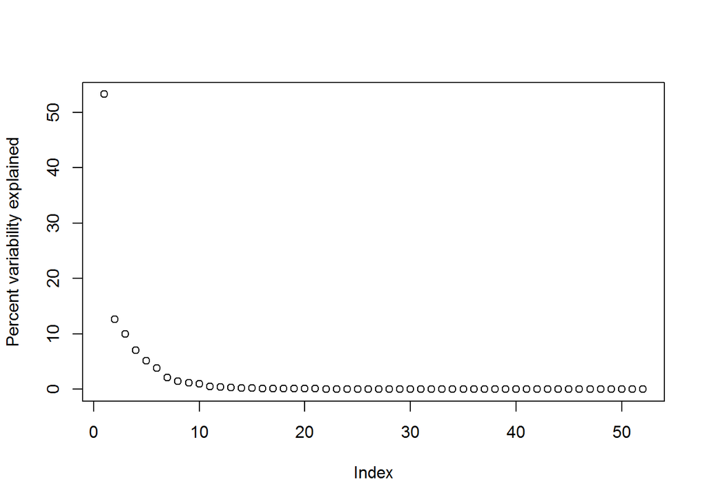

```r
tr_m <- as.matrix(tr[-53])
svdo <- svd(tr_m)
plot(svdo$d^2/sum(svdo$d^2)*100,ylab="Percent variability explained")
```

Lets take a look at first right singular vector. As we can see there are clear patterns there - that are driven by just a few of the features. This is true also for the other 5 most influential components (so I’m not going to annoy you showing them all).

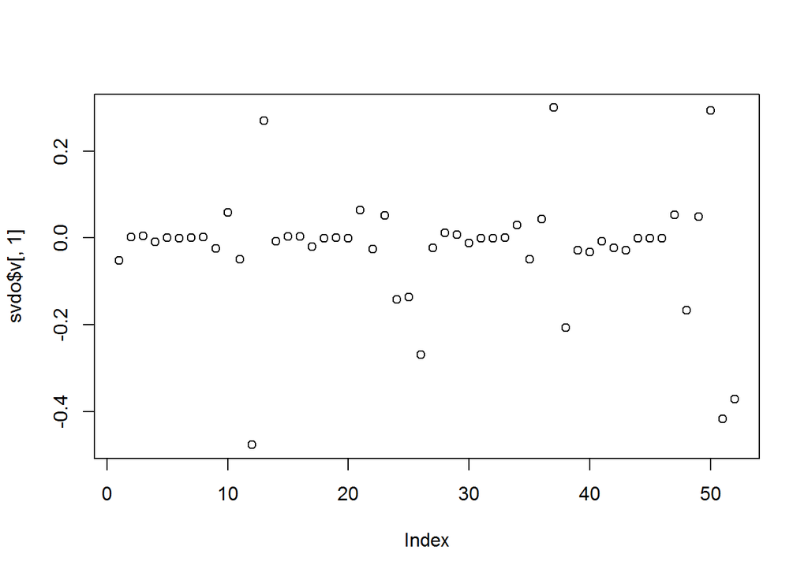

```r
plot(svdo$v[,1])
```

So lets select from (first 6) singular vectors just the columns that drives the patterns in the set - and continue exploration with them only:

```r
c1 <- which(abs(svdo$v[,1]) > 0.1)
c2 <- which(abs(svdo$v[,2]) > 0.1)
c3 <- which(abs(svdo$v[,3]) > 0.1)
c4 <- which(abs(svdo$v[,4]) > 0.1)
c5 <- which(abs(svdo$v[,5]) > 0.1)
c6 <- which(abs(svdo$v[,6]) > 0.1)
col_ix <- unique(c(c1, c2, c3, c4, c5, c6))
tr <- cbind(tr[,col_ix], classe=factor(tr$classe))
```

### Density plots

Lets check how density plots looks like of the most meaningful features:

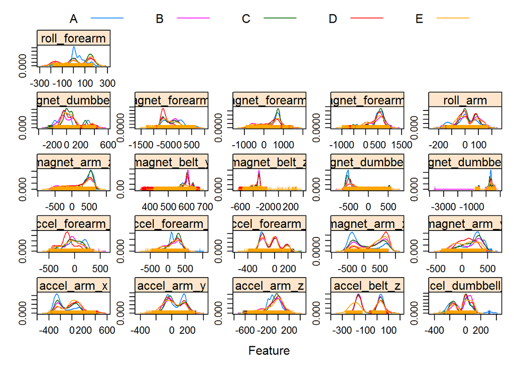

```r
featurePlot(x = tr[-22],
            y = tr$classe,
            plot = "density",
            ## make it prettier
            scales = list(x = list(relation="free"),
                          y = list(relation="free")),
            adjust = 1.5,
            pch = "|",
            layout = c(5, 5),
            auto.key = list(columns = 5))
```

Based on density plots looks like there are less useful features than other - for example accel_forearm_z, accel_belt_z etc. It is always good idea to fit regression model and perform anova to decide what is meaningful after adjusting for the proper predictors. Still this set of features looks meaningful - so I’m not going to reduce it more.

## Pre-processing

Since there are no missing values I’ll just go for centering and scaling. I’m also going to extract sample of the set and train the model on it (unfortunately caret is not really shining with performance…).

```r
set.seed(333)
pro <- preProcess(tr[-22], method=c("center", "scale"))
tr <- cbind(predict(pro, tr[-22]), classe=tr$classe)
flg_tr <- createDataPartition(tr$classe, p=0.3)[[1]]
training <- tr[flg_tr,]
```

## Model Fitting

Decided to use Random Forest model with 5 fold cross-validation:

```r
set.seed(333)
tr_ctrl <- trainControl(method="cv", number=5)
fit_rf <- train(classe~., data=training, method="rf", trControl=tr_ctrl, allowParallel=TRUE, prox=TRUE)
```

## Model Accuracy

Lets take a look at model summary - and best model summary:

```r
print(fit_rf)
```

```
## Random Forest
##
## 5889 samples
##   21 predictor
##    5 classes: 'A', 'B', 'C', 'D', 'E'
##
## No pre-processing
## Resampling: Cross-Validated (5 fold)
## Summary of sample sizes: 4711, 4711, 4710, 4712, 4712
## Resampling results across tuning parameters:
##
##   mtry  Accuracy   Kappa
##    2    0.9493977  0.9359323
##   11    0.9468511  0.9327405
##   21    0.9361540  0.9191804
##
## Accuracy was used to select the optimal model using  the largest value.
## The final value used for the model was mtry = 2.
```

```r
print(fit_rf$finalModel)
```

```
##
## Call:
##  randomForest(x = x, y = y, mtry = param$mtry, proximity = TRUE,      allowParallel = TRUE)
##                Type of random forest: classification
##                      Number of trees: 500
## No. of variables tried at each split: 2
##
##         OOB estimate of  error rate: 4.3%
## Confusion matrix:
##      A    B   C   D    E class.error
## A 1658   10   4   1    1 0.009557945
## B   42 1051  30  10    7 0.078070175
## C    3   35 982   4    3 0.043816943
## D    3    7  45 904    6 0.063212435
## E    1   12   5  24 1041 0.038781163
```